# Project - Classify Type of Patient from the biomechanical features of orthopedic patients.

# import data 3C_weka.csv for 3 Class Classifcation and repeat all the steps which are given above.

```python
_3c = pd.read_csv("./3Classdata.csv")
```

```python
# viewing head of the dataset
_3c.head()
```

|  | pelvic_incidence | pelvic_tilt | lumbar_lordosis_angle | sacral_slope | pelvic_radius | degree_spondylolisthesis | class |
| --- | --- | --- | --- | --- | --- | --- | --- |
| 0 | 63.027818 | 22.552586 | 39.609117 | 40.475232 | 98.672917 | -0.254400 | Hernia |
| 1 | 39.056951 | 10.060991 | 25.015378 | 28.995960 | 114.405425 | 4.564259 | Hernia |
| 2 | 68.832021 | 22.218482 | 50.092194 | 46.613539 | 105.985135 | -3.530317 | Hernia |
| 3 | 69.297008 | 24.652878 | 44.311238 | 44.644130 | 101.868495 | 11.211523 | Hernia |
| 4 | 49.712859 | 9.652075 | 28.317406 | 40.060784 | 108.168725 | 7.918501 | Hernia |

```python
# viewing tail of the dataset
_3c.tail()
```

|  | pelvic_incidence | pelvic_tilt | lumbar_lordosis_angle | sacral_slope | pelvic_radius | degree_spondylolisthesis | class |
| --- | --- | --- | --- | --- | --- | --- | --- |
| 305 | 47.903565 | 13.616688 | 36.000000 | 34.286877 | 117.449062 | -4.245395 | Normal |
| 306 | 53.936748 | 20.721496 | 29.220534 | 33.215251 | 114.365845 | -0.421010 | Normal |
| 307 | 61.446597 | 22.694968 | 46.170347 | 38.751628 | 125.670725 | -2.707880 | Normal |
| 308 | 45.252792 | 8.693157 | 41.583126 | 36.559635 | 118.545842 | 0.214750 | Normal |
| 309 | 33.841641 | 5.073991 | 36.641233 | 28.767649 | 123.945244 | -0.199249 | Normal |

```python
# Checking for empty or NaN data in all the column
for column in _3c.columns:
    data = _3c[column].isnull().sum()
    print("Checking null in column '{}' and its {}.".format(column,data))
```

```
Checking null in column 'pelvic_incidence' and its 0.
Checking null in column 'pelvic_tilt' and its 0.
Checking null in column 'lumbar_lordosis_angle' and its 0.
Checking null in column 'sacral_slope' and its 0.
Checking null in column 'pelvic_radius' and its 0.
Checking null in column 'degree_spondylolisthesis' and its 0.
Checking null in column 'class' and its 0.
```

- On checking the columns in _3c dataframe I see no null values in it.

```python
# Getting the unique values in column Values
unquievalues = _3c['class'].unique()
print("Unique Values in dataset _3c are:")
for item in unquievalues:
    result = np.where(unquievalues == item)
    print(str(result[0][0]+1),item)
```

```
Unique Values in dataset _3c are:
1 Hernia
2 Spondylolisthesis
3 Normal
```

- The unique values in column class are Hernia, Spondylolisthesis and Normal.

```
array([[<matplotlib.axes._subplots.AxesSubplot object at 0x000002350BA1D5F8>,
      dtype=object)
```

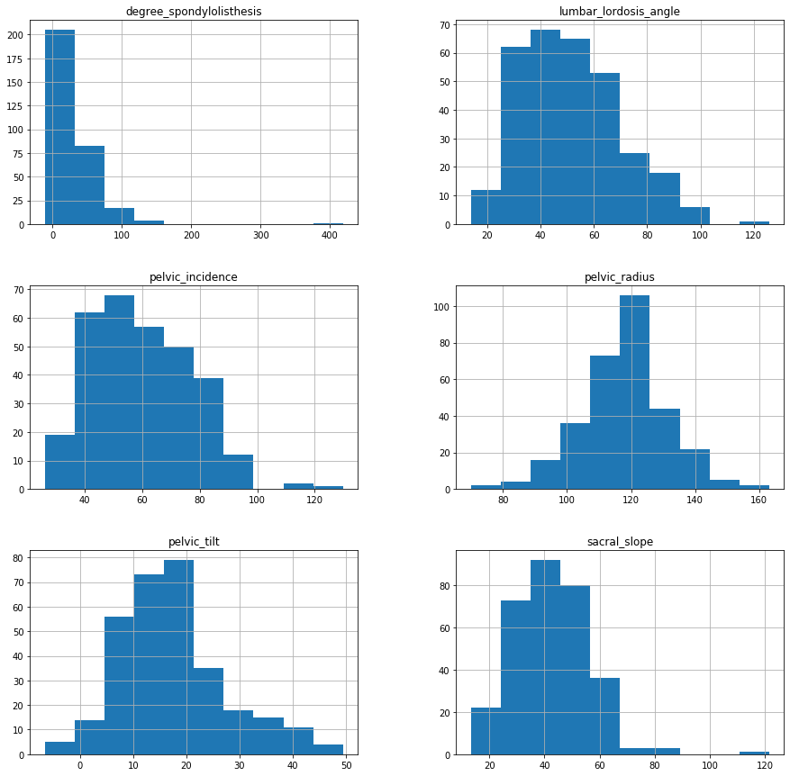

```python
pd.DataFrame.hist(_3c, figsize=(15,15))
```

### Conclusion on Distribution of the Independent Varibles

- The data points in column pelvic_radius is normally distributed.
- pelvic_tilt numeric,sacral_slope,pelvice_incidence,lumbar_lordosis_angle are columns that has a right skew.
- degree_spondylolisthesis starts with a peak and then skews to the right.

### Datatype information on the dataset

```python
_3c.info()
```

```
<class 'pandas.core.frame.DataFrame'>
RangeIndex: 310 entries, 0 to 309
Data columns (total 7 columns):
pelvic_incidence            310 non-null float64
pelvic_tilt                 310 non-null float64
lumbar_lordosis_angle       310 non-null float64
sacral_slope                310 non-null float64
pelvic_radius               310 non-null float64
degree_spondylolisthesis    310 non-null float64
class                       310 non-null object
dtypes: float64(6), object(1)
memory usage: 17.0+ KB
```

### Conclusion:

- All the columns in the dataset except for 'class' column, the datatype is float.
- The 'class' column has the object as its datatype.
- We have 310 records in every column.
- We have already verified that non of the column has empty or NaN as value.

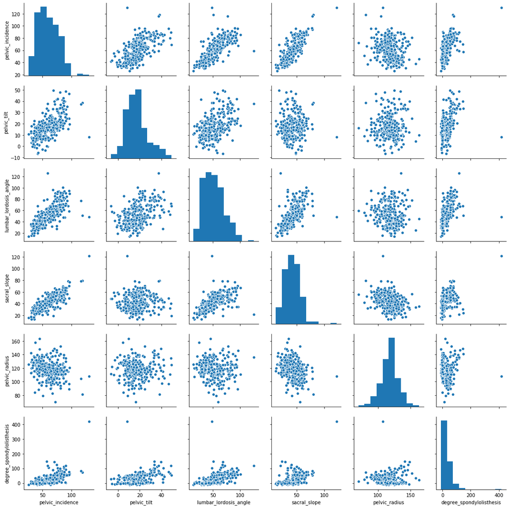

```python
sns.pairplot(_3c)
```

```python
# converting the categorical values to numeric values(imputation)
_3c['classnumeric'] = _3c['class'].map({'Normal': 1, 'Hernia':0, 'Spondylolisthesis':2})
```

```python
_3c.head()
```

|  | pelvic_incidence | pelvic_tilt | lumbar_lordosis_angle | sacral_slope | pelvic_radius | degree_spondylolisthesis | class | classnumeric |
| --- | --- | --- | --- | --- | --- | --- | --- | --- |
| 0 | 63.027818 | 22.552586 | 39.609117 | 40.475232 | 98.672917 | -0.254400 | Hernia | 0 |
| 1 | 39.056951 | 10.060991 | 25.015378 | 28.995960 | 114.405425 | 4.564259 | Hernia | 0 |
| 2 | 68.832021 | 22.218482 | 50.092194 | 46.613539 | 105.985135 | -3.530317 | Hernia | 0 |
| 3 | 69.297008 | 24.652878 | 44.311238 | 44.644130 | 101.868495 | 11.211523 | Hernia | 0 |
| 4 | 49.712859 | 9.652075 | 28.317406 | 40.060784 | 108.168725 | 7.918501 | Hernia | 0 |

```python
# Creating Independent Variables
XX =  _3c.drop(['class'], axis=1)
```

```python
# Creating Target Variables
YY = _3c['classnumeric']
```

```python
# Require library for converting an array to standard form
from sklearn.preprocessing import StandardScaler
```

```python
scalar = StandardScaler()
XX_Normalized = scalar.fit_transform(XX)
print("XX_Normalized Data :")
print("___________________________________________________________________")
print(XX_Normalized)
```

```
XX_Normalized Data :
___________________________________________________________________
[[ 0.14708636  0.50136873 -0.6651769  ... -1.4476468  -0.70805942
  -1.67541563]
 [-1.24586434 -0.74876898 -1.45300075 ... -0.26438488 -0.57955637
  -1.67541563]
 [ 0.4843695   0.46793218 -0.09926175 ... -0.89768556 -0.79542095
  -1.67541563]
 ...
 [ 0.05520137  0.51561812 -0.31097748 ...  0.58289256 -0.77348834
  -0.37696852]
 [-0.88582307 -0.88565951 -0.55861259 ...  0.04702109 -0.69554822
  -0.37696852]
 [-1.54892681 -1.24785954 -0.82539423 ...  0.45311695 -0.70658867
  -0.37696852]]
```

```python
# import library to seprate data as test and train
from sklearn.model_selection import train_test_split
```

```python
# Creating test and training dataset.
XX_train, XX_test, YY_train, YY_test = train_test_split(XX, YY, test_size=.3, random_state=7)
```

```python
# importing libraries for KNN model
from sklearn.neighbors import KNeighborsClassifier
from sklearn.metrics import accuracy_score
```

```python
# initially running with K as 3, 5, 9
for k in [3, 5, 9]:
    KNN = KNeighborsClassifier(n_neighbors=k)
    KNN.fit(XX_train, YY_train)
    YY_pred =  KNN.predict(XX_test)
    knnscore = KNN.score(XX_test, YY_test)
    accscore = accuracy_score(YY_test, YY_pred)
    print("When K is : {}, accuracy using KNN.Score : {} and accuracy using accuracy_score : {}."
          .format(k, knnscore, accscore))
```

```
When K is : 3, accuracy using KNN.Score : 0.8602150537634409 and accuracy using accuracy_score : 0.8602150537634409.
When K is : 5, accuracy using KNN.Score : 0.8709677419354839 and accuracy using accuracy_score : 0.8709677419354839.
When K is : 9, accuracy using KNN.Score : 0.8494623655913979 and accuracy using accuracy_score : 0.8494623655913979.
```

```python
# Extending K from 1 to 19 to check if the models yeilds better accuracy if K is increased.
ac__score = []
knn__score = []

for k in range(1,21,2):
    KNN = KNeighborsClassifier(n_neighbors=k)
    KNN.fit(XX_train, YY_train)
    YY_pred =  KNN.predict(XX_test)
    acscore = accuracy_score(YY_test, YY_pred)
    ac__score.append((acscore,k))
    _knnscore = KNN.score(XX_test, YY_test)
    knn__score.append((_knnscore,k))
    print("When K is : {}, accuracy using KNN.Score : {} and accuracy using accuracy_score : {}."
          .format(k, _knnscore, acscore))

maxacc = max(ac__score)
maxknnscore = max(knn__score)
```

```
When K is : 1, accuracy using KNN.Score : 0.8387096774193549 and accuracy using accuracy_score : 0.8387096774193549.
When K is : 3, accuracy using KNN.Score : 0.8602150537634409 and accuracy using accuracy_score : 0.8602150537634409.
When K is : 5, accuracy using KNN.Score : 0.8709677419354839 and accuracy using accuracy_score : 0.8709677419354839.
When K is : 7, accuracy using KNN.Score : 0.8494623655913979 and accuracy using accuracy_score : 0.8494623655913979.
When K is : 9, accuracy using KNN.Score : 0.8494623655913979 and accuracy using accuracy_score : 0.8494623655913979.
When K is : 11, accuracy using KNN.Score : 0.8387096774193549 and accuracy using accuracy_score : 0.8387096774193549.
When K is : 13, accuracy using KNN.Score : 0.8602150537634409 and accuracy using accuracy_score : 0.8602150537634409.
When K is : 15, accuracy using KNN.Score : 0.8709677419354839 and accuracy using accuracy_score : 0.8709677419354839.
When K is : 17, accuracy using KNN.Score : 0.8494623655913979 and accuracy using accuracy_score : 0.8494623655913979.
When K is : 19, accuracy using KNN.Score : 0.8924731182795699 and accuracy using accuracy_score : 0.8924731182795699.
```

```python
# KNN.score when k is 19.
KNN.score(XX_test, YY_test)
```

```
0.8924731182795699
```

```python
# Fininding optimal K
print("The optimal number of K neighbours is {} with accuracy_score of {} %".format(maxacc[1], round(maxacc[0] * 100, 3)))
print("The optimal number of K neighbours is {} with KNN.Score of {} %.".format(maxknnscore[1], round(maxknnscore[0] * 100, 3)))
```

```
The optimal number of K neighbours is 19 with accuracy_score of 89.247 %
The optimal number of K neighbours is 19 with KNN.Score of 89.247 %.
```

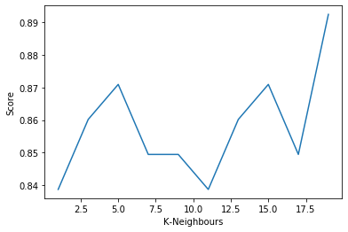

```python
# Visualizating the performance of the model in terms of accuracy
score, k = zip(*knn__score)
plt.plot(k, score)
plt.xlabel("K-Neighbours")
plt.ylabel("Score")
plt.show()
```